# Introduction to tci package

# Introduction

Target-controlled infusion (TCI) systems calculate infusion rates required to reach target concentrations or effects within a patient. Where pharmacokinetic (PK) and pharmacodynamic (PD) models describe a time course of concentrations or effects, respectively, associated with a series of doses, TCI algorithms calculate the inverse relationship: what doses must be administered to achieve target responses?

The `tci` package implements TCI algorithms for PK and PK-PD models for drugs described by compartmental models and administered via intravenous infusion. The package provides closed-form solutions for one, two, or three compartment mammillary models (i.e., all peripheral compartments are joined to a central compartment), as well as a three-compartment model with an adjoining effect-site. PK model code is based on solutions published by Abuhelwa, Foster, and Upton (2015) and models are implemented in C++ via `Rcpp`. TCI algorithms for plasma- and effect-site targeting are implemented based on work by Jacobs (1990) and Shafer and Gregg (1992), respectively. Users can specify alternative PK models or TCI algorithms. See the `custom` vignette for further details.

```r
library(tci)
library(ggplot2)   # ggplot for plotting
library(gridExtra) # arrangeGrob to arrange plots
library(reshape2)  # melt function
```

## `pkmod` and `poppkmod` object classes

The `tci` package is built around S3 classes `pkmod` and `poppkmod`, created with the functions `pkmod` and `poppkmod`, respectively. `pkmod` objects serve as containers for 1) functions implementing the structural PK model (e.g., a 1-compartment model with first-order elimination) and the PD model, if applicable, 2) the parameters for the respective functions, and 3) initial concentrations, and 4) information relevant for simulating observations or implementing TCI control, such as the compartment number associated with observations or with an effect-site. `poppkmod` are wrapper objects that contain one or more `pkmod` objects associated with published population PK models: the Marsh, Schnider, and Eleveld models for propofol, and the Minto, Kim, and Eleveld models for remifentanil.

Both `pkmod` and `poppkmod` objects have associated `predict` and `simulate` methods that can be used to predict concentrations and simulate observations (PK or PD) given an infusion schedule. Infusion schedules, in turn, are created either manually via `inf_manual` or by applying a TCI algorithm to reach designated targets via `inf_tci`. `pkmod` objects are additionally equipped with a `update` method that allows for model components (e.g., parameter values, initial concentrations) to be easily modified. Both `predict` and `simulate` methods pass additional arguments via the ellipses argument, `...`, to `update.pkmod` to readily allow for prediction or simulation under different conditions.

Examples in this vignette will focus on illustrating the lower-level functions of `tci` applied to `pkmod` objects. See the vignette on population PK models for illustration of higher-level functions and applications to population PK models for propofol and remifentanil.

# Examples

Equations implementing 1-,2-,3-compartment and 3-compartment-effect structural PK models are included in the `tci` package. The function `pkmod` will automatically infer the correct structure based on the parameter names.

```r
# 1-compartment model
(mod1cpt <- pkmod(pars_pk = c(cl = 10, v = 15)))
```

```
#> tci pkmod object
#> See ?update.pkmod to modify or add elements
#>
#> PK model
#>  1-compartment PK model
#>  PK parameters: cl = 10, v = 15
#>  Initial concentrations: (0)
#>  Plasma compartment: 1
#>  Effect compartment: 1
#>
#> Simulation
#>  Additive error SD: 0
#>  Multiplicative error SD: 0
#>  Logged response: FALSE
```

```r
# 3-compartment model with effect site
(mod3ecpt <- pkmod(pars_pk = c(cl = 10, q2 = 2, q3 =20, v = 15, v2 = 30, v3 = 50, ke0 = 1.2)))
```

```
#> tci pkmod object
#> See ?update.pkmod to modify or add elements
#>
#> PK model
#>  4-compartment PK model
#>  PK parameters: cl = 10, q2 = 2, q3 = 20, v = 15, v2 = 30, v3 = 50, ke0 = 1.2
#>  Initial concentrations: (0,0,0,0)
#>  Plasma compartment: 1
#>  Effect compartment: 4
#>
#> Simulation
#>  Additive error SD: 0
#>  Multiplicative error SD: 0
#>  Logged response: FALSE
```

Acceptable parameter names can be viewed by calling `list_parnms()`. Less-commonly used parameters, such as clearance from a peripheral compartment, are also permissible.

```r
# acceptable parameter names
list_parnms()
```

```
#> Acceptable names for 'pars_pk' vector (case-insensitive)
#>
#> First compartment options
#>  Central volume: 'v','v1'
#>  Elimination: 'cl','cl1','k10','ke'
#>
#> Second compartment options
#>  Peripheral volume: 'v2'
#>  Transfer: 'q','q2','k12','k21'
#>  Elimination: 'cl2','k20'
#>
#> Third compartment options
#>  Second peripheral volume: 'v3'
#>  Transfer: 'q3','k13','k31'
#>  Elimination: 'cl3','k30'
#>
#> Effect-site
#>  Elimination: 'ke0'
```

Elements of `pkmod` objects can be modified through an `update.pkmod` method. Perhaps most usefully, this allows for partial modifications to PK-PD parameters. For example, the effect-site equilibrium constant can be easily updated.

```r
update(mod3ecpt, pars_pk = c(ke0 = 0.9), init = c(1,0.2,0.3,1))
```

```
#> tci pkmod object
#> See ?update.pkmod to modify or add elements
#>
#> PK model
#>  4-compartment PK model
#>  PK parameters: cl = 10, q2 = 2, q3 = 20, v = 15, v2 = 30, v3 = 50, ke0 = 0.9
#>  Initial concentrations: (1,0.2,0.3,1)
#>  Plasma compartment: 1
#>  Effect compartment: 4
#>
#> Simulation
#>  Additive error SD: 0
#>  Multiplicative error SD: 0
#>  Logged response: FALSE
```

Most functions in the `tci` package pass additional arguments to `update.pkmod` allowing for easy modification of `pkmod` objects as needed.

## Infusion schedules

```r
# single infusion
(single_inf <- inf_manual(inf_tms = 0, duration = 0.5, inf_rate = 100))
```

```
#>      begin end inf_rate
#> [1,]     0 0.5      100
```

```r
# multiple infusions
(multi_inf <- inf_manual(inf_tms = c(0,3,6), duration = c(1,0.5,0.25), inf_rate = 100))
```

```
#>      begin  end inf_rate
#> [1,]   0.0 1.00      100
#> [2,]   1.0 3.00        0
#> [3,]   3.0 3.50      100
#> [4,]   3.5 6.00        0
#> [5,]   6.0 6.25      100
```

Typically, however, the `inf_tci` will be used to calculate infusion rates required to reach specified targets. `inf_tci` requires 1) a set of target concentrations (or PD response values) and corresponding times at which the target is set, and 2) a `pkmod` object. It has “plasma” and “effect” settings, implementing the Jacobs and Shafer algorithms, respectively. Custom algorithms can be specified through the `custom_alg` argument. See the vignette on custom models and algorithms for more details.

```r
# plasma targeting for one-compartment model
inf_1cpt <- inf_tci(target_vals = c(2,3,4,4), target_tms = c(0,2,3,10),
                    pkmod = mod1cpt, type = "plasma")
head(inf_1cpt)
```

```
#>        begin     end inf_rate Ct c1_start c1_end
#> [1,] 0.00000 0.16667 190.1851  2        0      2
#> [2,] 0.16667 0.33333  20.0000  2        2      2
#> [3,] 0.33333 0.50000  20.0000  2        2      2
#> [4,] 0.50000 0.66667  20.0000  2        2      2
#> [5,] 0.66667 0.83333  20.0000  2        2      2
#> [6,] 0.83333 1.00000  20.0000  2        2      2
```

```r
# effect-site targeting for three-compartment effect site model
inf_3ecpt <- inf_tci(target_vals = c(2,3,4,4), target_tms = c(0,2,3,10),
                     pkmod = mod3ecpt, type = "effect")
head(inf_3ecpt)
```

```
#>        begin     end inf_rate Ct c1_start   c2_start  c3_start  c4_start
#> [1,] 0.00000 0.16667 643.6921  2 0.000000 0.00000000 0.0000000 0.0000000
#> [2,] 0.16667 0.33333   0.0000  2 6.033672 0.03532348 0.2079682 0.5966263
#> [3,] 0.33333 0.50000   0.0000  2 4.301795 0.09138590 0.5235366 1.4096671
#> [4,] 0.50000 0.66667   0.0000  2 3.136188 0.13103476 0.7267367 1.8178340
#> [5,] 0.66667 0.83333  19.3835  2 2.350071 0.15960595 0.8548449 1.9785480
#> [6,] 0.83333 1.00000   0.0000  2 2.000000 0.18174014 0.9390928 2.0109479
#>        c1_end     c2_end    c3_end    c4_end
#> [1,] 6.033672 0.03532348 0.2079682 0.5966263
#> [2,] 4.301795 0.09138590 0.5235366 1.4096671
#> [3,] 3.136188 0.13103476 0.7267367 1.8178340
#> [4,] 2.350071 0.15960595 0.8548449 1.9785480
#> [5,] 2.000000 0.18174014 0.9390928 2.0109479
#> [6,] 1.586605 0.19939667 0.9931813 1.9678507
```

By default, plasma- and effect-targeting algorithms are updated in increments of 1/6. If a PK model elimination parameters have units of minutes (as do commonly used models for the anesthetic propofol), this will correspond to updating TCI targets at 10-second intervals. If elimination rates are in different units, such as hours, then the TCI update frequency should be modified by the argument `dtm`.

## Predict and simulate methods

The infusion schedule can be applied to the `pkmod` object using `predict.pkmod` or `simulate.pkmod` methods to predict concentrations or simulate observations, respectively. Using the three-compartment model as illustration

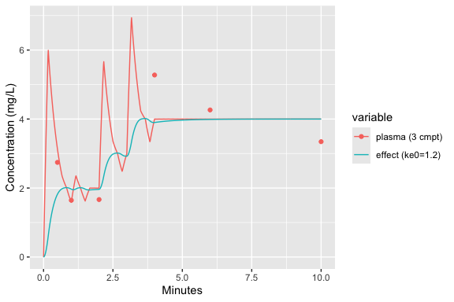

```r
# prediction/observation times
tms_pred <- seq(0,10,0.01)
tms_obs <- c(0.5,1,2,4,6,10)

pre <- predict(mod3ecpt, inf = inf_3ecpt, tms = tms_pred)
obs <- simulate(mod3ecpt, seed = 1, inf = inf_3ecpt, tms = tms_obs, sigma_mult = 0.2)

# plot results
dat <- data.frame(time = tms_pred, `plasma (3 cmpt)` = pre[,"c1"],
                  `effect (ke0=1.2)` = pre[,"c4"],
                  check.names = FALSE)
datm <- melt(dat, id = "time")
dat_obs <- data.frame(time = tms_obs, con = obs, variable = "plasma (3 cmpt)")

p <- ggplot(datm, aes(x = time, y = value, color = variable)) +
  geom_line() +
  geom_point(data = dat_obs, aes(x = time, y = con)) +
  xlab("Minutes") + ylab("Concentration (mg/L)")
p
```

Notably, the `pkmod` object used in the predict and simulate methods does not need to be the same as the one used to calculate the infusion schedule. This permits the user to evaluate the effect of model misspecification either 1) by passing different parameter values to `update.pkmod` via `predict.pkmod` or `simulate.pkmod`, or 2) by using a different `pkmod` object.

To illustrate the parameter misspecification, we can evaluate predictions with a new effect-site equilibrium constant.

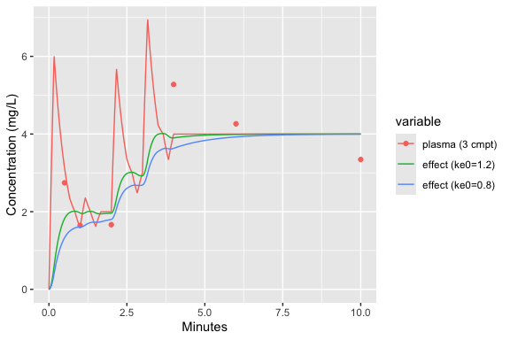

```r
# evaluate with different ke0 parameter
pre_misspec <- predict(mod3ecpt, inf = inf_3ecpt, tms = tms_pred,
                       pars_pk = c(ke0 = 0.8))
dat_misspec <- data.frame(pre_misspec, variable = "effect (ke0=0.8)", time = tms_pred)
p + geom_line(data = dat_misspec, aes(x = time, y = c4, color = variable))
```

To illustrate structural model misspecification, we can consider the case where PK are described by a one-compartment model, but infusions were calculated according to a three-compartment model.

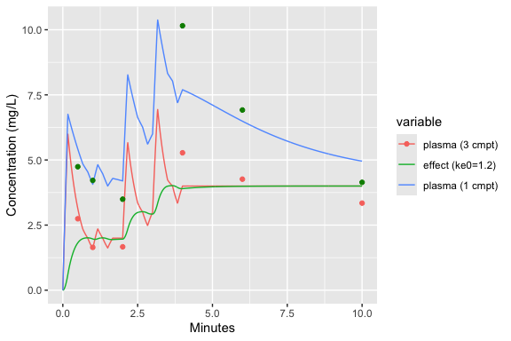

```r
# predicted concentrations
pre_1cpt <- predict(mod1cpt, inf = inf_3ecpt, tms = tms_pred)
dat_1cpt <- data.frame(pre_1cpt, variable = "plasma (1 cmpt)", time = tms_pred)
# simulated observations
obs_1cpt <- simulate(mod1cpt, seed = 1, inf = inf_3ecpt, tms = tms_obs, sigma_mult = 0.2)

p + geom_line(data = dat_1cpt, aes(x = time, y = c1, color = variable)) +
  geom_point(data = data.frame(time = tms_obs, con = obs_1cpt, variable = "plasma (1 cmpt)"),
           aes(x = time, y = con), inherit.aes = FALSE, color = "green4")
```

## Extensions to PK-PD models

All of the functions in `tci` can be extended to include pharmacodynamic (PD) models. Unlike PK models, the equations describing PD models are typically invertible, allowing one to readily calculate the target effect-site concentration associated with a desired effect. The user, therefore, supplies to a `pkmod` functions implementing the PD response (i.e., compute response from concentrations), and its inverse (i.e., concentrations from a response), as well as associated parameter values.

Four-parameter E-max models are commonly used to describe PD responses and are implemented in `tci`. E-max models describe a response in terms of its minimum and maximum values, `emx` and `e0`, respectively, the concentration associated with 50% effect, `c50`, and the slope of the dose-response curve at c50, `gamma`. In anesthesia, the Bispectral Index (BIS) is a commonly used measurement of a patient’s depth of hypnosis and is often described by an E-max model. BIS is derived from EEG measurements and calibrated to vary between BIS=100, indicating a fully-alert state, and BIS=0, in which little brain activity is registered. BIS values between 40 and 60 typically indicate that a patient is sufficiently sedated for general anesthesia.

```r
modpd <- update(mod3ecpt, pdfn = emax, pdinv = emax_inv,
                 pars_pd = c(e0 = 100, emx = 100, c50 = 3.5, gamma = 2.2))
```

PD targets are passed along with the updated `pkmod` to `inf_tci`, which will assume values are PD values (unless overridden by the `ignore_pd` argument of `inf_tci`).

```r
inf_pd <- inf_tci(target_vals = c(70,60,50,50), target_tms = c(0,2,3,10), pkmod = modpd, type = "effect")
```

We can then similarly use `predict.pkmod` and `simulate.pkmod` methods to predict and simulate PD responses. BIS measurements may be collected at a rate of one observation per 10-20 seconds, depending on the BIS device settings.

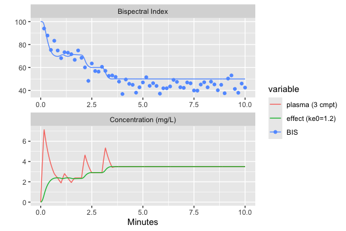

```r
# predict responses
pre_pd <- predict(modpd, inf = inf_pd, tms = tms_pred)
# pd observations: 10 sec = 1/6 min
tms_pd_obs <- seq(1/6,10,1/6)
# simulate responses with additive error and parameter misspecification
obs_pd <- simulate(modpd, seed = 1, inf = inf_pd, tms = tms_pd_obs, sigma_add = 5,
                   pars_pk = c(ke0 = 0.7), pars_pd = c(c50 = 3, gamma = 1.8))

# plot results
dat_pd <- data.frame(time = tms_pred, `plasma (3 cmpt)` = pre_pd[,"c1"],
                  `effect (ke0=1.2)` = pre_pd[,"c4"],
                  BIS = pre_pd[,"pdresp"],
                  check.names = FALSE)
dat_pdm <- melt(dat_pd, id = "time")
dat_pdm$type <- as.factor(ifelse(dat_pdm$variable == "BIS", "PD","PK"))
dat_pd_obs <- data.frame(time = tms_pd_obs, BIS = obs_pd,
                         type = factor("PD"), variable = "BIS")
levels(dat_pdm$type) <- levels(dat_pd_obs$type) <- c("Bispectral Index", "Concentration (mg/L)")

ggplot(dat_pdm, aes(x = time, y = value, color = variable)) +
  facet_wrap(type~., scales = "free", nrow = 2) +
  geom_line() +
  geom_point(data = dat_pd_obs, aes(x = time, y = BIS)) +
  xlab("Minutes") + ylab("")
```

## Open- and closed-loop control

Simulations with potential model misspecification are most easily implemented using the function `simulate_tci` which can be used for both `pkmod` and `poppkmod` classes. Required arguments to `simulate_tci` are 1) a prior PK model (`pkmod_prior`) that is used to calculate infusion rates and may be updated throughout the simulation if update times are provided, 2) a true PK model (`pkmod_true`) that is used to simulate observations, 3) TCI target values, 4) TCI target times, and 5) times to simulate observations. If update times are specified then Bayesian updates will be performed to update parameters based on the (simulated) data available at each time. Data processing delays can be incorporated through the argument `delay`.

To illustrate open-loop control, we simulate PK responses from a three-compartment model at times 1, 2, 3, 4, 8, and 12 over a 24 hour period in which effect-site targeting is used and the target concentration is raised from 2 mg/L to 4 mg/L.

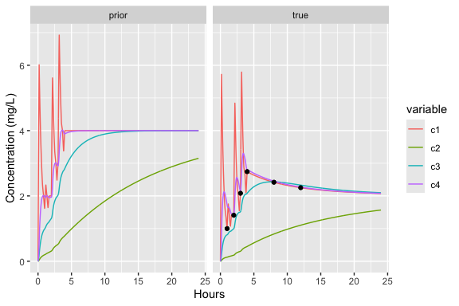

```r
mod_true  <- update(mod3ecpt, pars_pk = c(cl = 20, q2 = 1.5, ke0 = 1.8))
sim_ol <- simulate_tci(pkmod_prior = mod3ecpt,
                       pkmod_true = mod_true,
                       target_vals = c(2,3,4,4),
                       target_tms = c(0,2,3,24),
                       obs_tms = c(1,2,3,4,8,12),
                       seed = 1)
ggplot(melt(sim_ol$resp, id.vars = c("time","type"))) +
  geom_line(aes(x = time, y = value, color = variable)) +
  geom_point(data = sim_ol$obs, aes(x = time, y = obs)) +
  facet_wrap(~type) +
  labs(x = "Hours", y = "Concentration (mg/L)")
```

Closed-loop control is implemented by specifying a set of update times. For model parameters to be updated, `pkmod_prior` must have an “Omega” matrix specifying the variability in each parameter. This matrix is used as the prior variance-covariance matrix in the updates, while the prior model parameters are used as the prior point estimates.

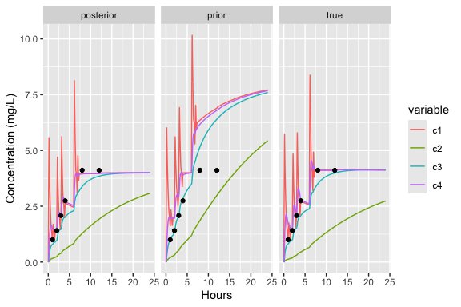

```r
mod3ecpt <- update(mod3ecpt, sigma_mult = 0.2,
                   Omega = matrix(diag(c(1.2,0.6,1.5,0.05)), 4,4,
                                  dimnames = list(NULL, c("cl","q2","v","ke0"))))
sim_cl <- simulate_tci(pkmod_prior = mod3ecpt,
                       pkmod_true = mod_true,
                       target_vals = c(2,3,4,4),
                       target_tms = c(0,2,3,24),
                       obs_tms = c(1,2,3,4,8,12),
                       update_tms = c(6,12,16),
                       delay = 0,
                       seed = 1)
ggplot(melt(sim_cl$resp, id.vars = c("time","type"))) +
  geom_line(aes(x = time, y = value, color = variable)) +
  geom_point(data = sim_cl$obs, aes(x = time, y = obs)) +
  facet_wrap(~type) +
  labs(x = "Hours", y = "Concentration (mg/L)")
```

### References

Abuhelwa, Ahmad Y., David J R Foster, and Richard N. Upton. 2015. “ADVAN-style analytical solutions for common pharmacokinetic models.” *Journal of Pharmacological and Toxicological Methods* 73: 42–48. https://doi.org/10.1016/j.vascn.2015.03.004.

Jacobs, James R. 1990. “Algorithm for Optimal Linear Model-Based Control with Application to Pharmacokinetic Model-Driven Drug Delivery.” *IEEE Transactions on Biomedical Engineering* 37 (1): 107–9. https://doi.org/10.1109/10.43622.

Shafer, Steven L., and Keith M. Gregg. 1992. “Algorithms to rapidly achieve and maintain stable drug concentrations at the site of drug effect with a computer-controlled infusion pump.” *Journal of Pharmacokinetics and Biopharmaceutics* 20 (2): 147–69. https://doi.org/10.1007/BF01070999.